# PSYC753 Data Fluency

*November 2020*

This workbook contains details of the four sessions given by **Chris Berry**:

- Week 16 (9/11/20). Building models 1: Multiple continuous predictors
- Week 17 (16/11/20). Building models 2: Comparing models
- Week 18 (23/11/20). Fitting curves
- Week 19 (30/11/20). Q&A Support session

It also contains details of the Data Visualisation and Analysis **assessment**.

(Materials for sessions by Ben Whalley can be found at https://benwhalley.github.io/datafluency/)

Use the left and right arrows to navigate through this workbook.

# 1 Building models 1

*November 2020*

### 1.0.1 In brief

> Models need to be *appropriately complex*. That is, we want to make models that represent our theories for the underlying causes of our data. Often this means adding many variables to a regression model. But we won’t always be sure which variables to add. Adding multiple variables also brings challenges. Where predictors are highly correlated (termed **multicollinearity**) then model results can be confusing.

## 1.1 Multiple regression with several continuous predictors

- Slides for the session

### 1.1.1 Overview

So far, you have used regression to predict an outcome variable from a predictor variable. For example, can we predict *academic performance* from *hours of study*?

You’ve also used it to determine whether the relation between two variables differs according to a categorical variable. Does the relation between academic performance and hours of study, for example, differ for *men* and *women*?

We often want to determine the extent to which an outcome variable is predicted by **several continuous predictors**.

For example, in addition to hours of study, a person’s *IQ* or *academic interest* might also predict their academic performance. We may want to add these predictors to a model because it may serve to *improve* the prediction of academic performance.

Today, we will:

- learn how to conduct a multiple regression with several continuous predictor variables
- evaluate the regression model with statistics ($R^2$, *F*-statistic, *t*-values)
- use Venn diagrams to help conceptualise the contribution of predictors to a model

**Simple vs. multiple regression**

- **Simple regression** is a linear model of the relationship between *one outcome variable and one predictor variable*. For example, can we predict `exam performance` on the basis of `IQ` scores?
- **Multiple regression** is a linear model of the relationship between *one outcome variable and more than one predictor variable*. For example, can we predict `exam performance`based on `IQ` scores *and* `attendance` at lectures?

## 1.2 Analysing the model

Suppose we want to construct a model to predict final university exam scores. This is the task faced by some admissions tutors! We’ll start off with a simple regression model, then work up to multiple regression.

Load the `ExamData` dataset from https://bit.ly/37GkvJg. This contains exam scores for students taking a university course. (Make sure `tidyverse` is loaded first!)

**Learning tip**

Try typing out the code today if you usually cut and paste it to R!

```r
ExamData <- read_csv('https://bit.ly/37GkvJg')

ExamData %>% head()
> # A tibble: 6 x 7
>   finalex entrex   age project    iq proposal attendance
>     <dbl>  <dbl> <dbl>   <dbl> <dbl>    <dbl>      <dbl>
> 1      38     44  21.9      50   110       44          0
> 2      49     40  22.6      75   120       70          0
> 3      61     43  21.8      54   119       54          0
> 4      65     42  22.5      60   125       53          0
> 5      69     44  21.9      82   121       73          0
> 6      73     46  21.8      65   140       62          0
```

These are the variables in `ExamData`:

- `finalex`: final examination marks
- `entrex`: entrance examination marks
- `age`: age in years
- `project`: dissertation project marks
- `iq`: IQ score
- `proposal`: dissertation proposal grade
- `attendance`: 1 = high attendance; 0 = low attendance

First, let’s ask whether `finalex` is predicted by `entrex`. Plot these variables:

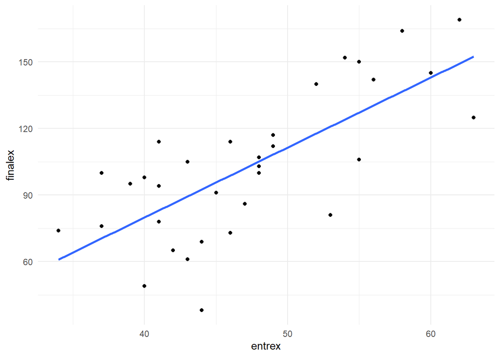

```r
ExamData %>%
  ggplot(aes(x = entrex, y = finalex)) +
  geom_point() +
  geom_smooth(se=F, method=lm)
```

There looks to be a positive association - students with higher entrance exam scores tend to have higher final exam scores. A good start!

To conduct the simple regression with `finalex` as the outcome variable, and `entrex` as the predictor variable, use `lm`:

```r
m1 <- lm(finalex ~ entrex, data = ExamData)
```

**Explanation**: `finalex ~ entrex` can be read as “`finalex` is predicted by `entrex`”. The model is stored in `m1`.

View the intercept of the regression line and the coefficient for `entrex`:

```r
m1
>
> Call:
> lm(formula = finalex ~ entrex, data = ExamData)
>
> Coefficients:
> (Intercept)       entrex
>     -46.305        3.155
```

We can therefore write the regression equation:

$Predicted\ final\ exam\ score = -46.305 + 3.155(entrance\ exam)$

Use `summary(m1)` to display statistical analysis of the model:

```r
summary(m1)
>
> Call:
> lm(formula = finalex ~ entrex, data = ExamData)
>
> Residuals:
>     Min      1Q  Median      3Q     Max
> -54.494 -21.185   3.733  18.124  30.969
>
> Coefficients:
>             Estimate Std. Error t value Pr(>|t|)
> (Intercept) -46.3045    25.4773  -1.817   0.0788 .
> entrex        3.1545     0.5324   5.925 1.52e-06 ***
> ---
> Signif. codes:  0 '***' 0.001 '**' 0.01 '*' 0.05 '.' 0.1 ' ' 1
>
> Residual standard error: 22.7 on 31 degrees of freedom
> Multiple R-squared:  0.531,   Adjusted R-squared:  0.5159
> F-statistic:  35.1 on 1 and 31 DF,  p-value: 1.52e-06
```

**Explanation of the output**:

**`Residuals:`** provides an indication of the discrepancy between the values of `finalex` predicted by the model (i.e., the regression equation) and the actual values of `finalex`. If the model does a good job in predicting `finalex`, the residuals should be relatively small.

- The difference between `Min` and `Max` gives us some idea of the range of error in the prediction of `finalex` scores. The difference in `3Q` and `1Q` is the interquartile range. The `median` of the residuals is 3.73.

**`Coefficients:`** contains tests of statistical significance for each of the coefficients. The values in the column headed `Pr(>|t|)` are the *p*-values associated with the *t*-values for the coefficients for each predictor. The *t*-values test a null hypothesis that the coefficients are equal to zero. A *p*-value less than .05 indicates that a predictor is statistically significant.

- The row for the `(intercept)` reports a *t*-test for whether the value of the intercept differs from zero. We’re not usually interested in this test (so don’t report it).
- The row for `entrex` tests whether the value of its coefficient (3.15) differs from zero. A coefficient of zero would be expected if the predictor explained no variance in the outcome variable. The coefficient for `entrex` (3.15) is clearly greater than zero. We can report this by saying that `extrex` is a statistically significant predictor of `finalex`, *b* = 3.15, *t*(31) = 5.92, *p* < .001.

**`Multiple R-squared:`** This is $R^2$ - the **proportion of variance in `finalex` explained by `entrex`**. Here, $R^2$ = 0.531. So approximately half of the variance in `finalex` is explained by `entrex`. It’s usually referred to simply as “R-squared” or $R^2$.

- $R^2$ is often reported as a percentage. To get this, simply multiply the value by 100. i.e., 0.531 x 100 = 53.10%.

**`Adjusted R-squared:`** is an estimate of $R^2$, but adjusted for the population. Despite the usefulness of this statistic, most studies still tend to report only the (unadjusted) $R^2$ value. If reporting the `Adjusted R-squared` value, be sure to label it clearly as such. Here, Adjusted R-squared = 0.52.

**`F-statistic:`** This compares the variance in `finalex` explained by the model with the variance that it does not explain (i.e., explained variance divided by unexplained variance). Higher values of *F* indicate that the model explains greater variance in an outcome variable. If the *p*-value associated with the *F*-statistic is less than .05, we can say that the model significantly predicts the outcome variable.

Hence, we can say that a model consisting of `entrex` alone is a significant predictor of `finalex`, *F*(1, 31) = 35.10, *p* < .001. Higher `entrex` scores tend to be associated with higher `finalex` scores. If our model did not explain any variance in `finalex`, we wouldn’t expect this to be statistically significant.

- In simple regression, the null hypothesis being tested on the *F*-statistic is that the slope of the regression line in the population is equal to zero. This is actually equivalent to the *t*-test on the `entrex` coefficient. So in simple regression, report the *F*-statistic for the overall regression or the *t*-test on the coefficient (not both). This equivalence between *F* and *t* does not hold true for multiple regression, as we shall see later.

**Now you have a go**

Run another simple regression:

- set `finalex` as the outcome variable and `project` as the predictor variable
- store the output in a variable with a different name (`m2`)
- then display the output of `m2` using `summary()`.

```r
m2 <- lm(finalex ~ project, data= ExamData)

summary(m2)
>
> Call:
> lm(formula = finalex ~ project, data = ExamData)
>
> Residuals:
>     Min      1Q  Median      3Q     Max
> -64.015 -21.686  -0.573  21.758  70.427
>
> Coefficients:
>             Estimate Std. Error t value Pr(>|t|)
> (Intercept)   4.6968    40.1677   0.117   0.9077
> project       1.4442     0.5861   2.464   0.0195 *
> ---
> Signif. codes:  0 '***' 0.001 '**' 0.01 '*' 0.05 '.' 0.1 ' ' 1
>
> Residual standard error: 30.32 on 31 degrees of freedom
> Multiple R-squared:  0.1638,  Adjusted R-squared:  0.1368
> F-statistic: 6.072 on 1 and 31 DF,  p-value: 0.01948
```

Answer the following: (report statistics to 2 decimal places)

- What is the value of the coefficient for `project`?
- What proportion of the variance in `finalex` is explained by `project`?: $R^2$ = (or %).
- Write down the regression equation (on a bit of paper).
- $Predicted\ final\ exam\ score = 4.70 + 1.44(project)$
- Is `project` alone a statistically significant predictor of `finalex`, as indicated by the *F*-statistic?
- Report the *F*-ratio in APA style, that is, in the form

  *F*(df1, df2) = *F*-statistic, *p* = *p*-value:

*F*(1, 31) = 6.07, *p* = .02

## 1.3 Conceptualising the variance explained by predictors

Venn diagrams are useful for understanding the variance that predictors explain in the outcome variable. They are especially useful for understanding what’s going on in multiple regression.

Suppose the rectangle below represents all of the *variance* in `finalex` to be explained.

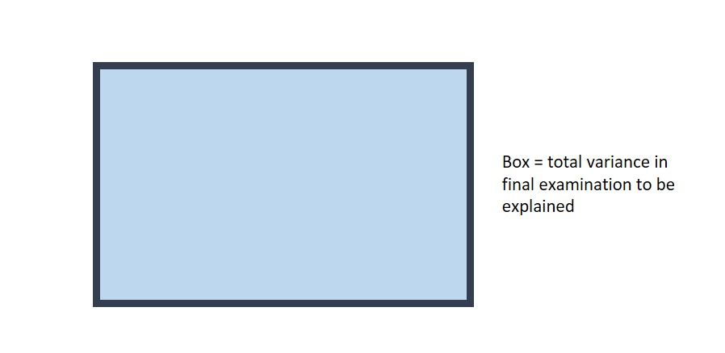

The area of the circle below represents the variance in `finalex` explained by `entrex` in the first simple regression we did. If this diagram were drawn to scale (it’s not), the area of the circle would be equal to the value of $R^2$ (i.e., 53.1% of the rectangle).

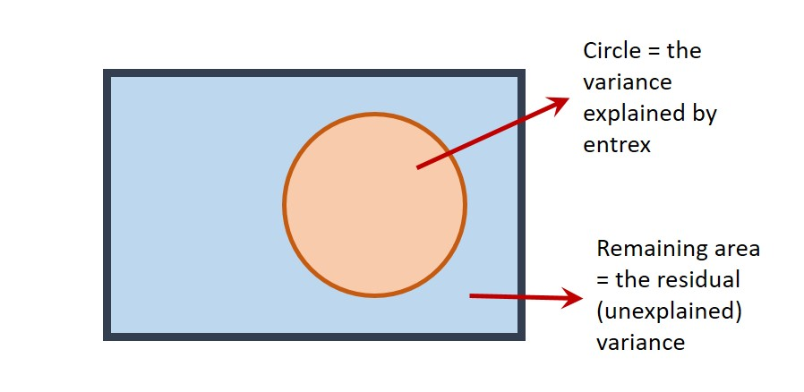

The part of the rectangle not inside the circle represents the variance in `finalex` that is *not* explained by the model (i.e., the unexplained or *residual* variance).

To *improve* the model, we can explore whether adding in other predictors to the model explains additional variance, thereby increasing the total $R^2$ of the model.

You might think that we can simply add in variables (circles, above) to the model as we wish, until all the residual variance has been explained. This seems fine to do until we learn that if we were to add as many predictors to the model as there are rows in our data (33 individuals in our `ExamData`), then we’d perfectly predict the outcome variable, and have an $R^2$ of 100%! This would be true even if the predictors consisted of random values. Our model would clearly be meaningless though. We ideally want to explain the outcome variable with relatively few predictors.

## 1.4 Adding predictor variables to the model

An issue that can arise when adding variables to a model is that predictors are usually correlated to some extent. This can make interpretation of multiple regressions tricky. For example, a predictor that is statistically significant in a simple regression may become non-significant in a multiple regression. Let’s see a demonstration of this!

We’ll now add `project` to the model with `entrex`. First, check the correlation between predictors:

```r
ExamData %>%
  select(entrex,project) %>%
  cor()
>            entrex   project
> entrex  1.0000000 0.2908253
> project 0.2908253 1.0000000
```

Our predictor variables are weakly correlated. We should keep this in mind going forward.

Now run a *multiple regression* to predict `finalex` from both `entrex` and `project`. Again, use `lm` but use the `+` symbol to add predictors to the model:

```r
m3 <- lm(finalex ~ entrex + project, data = ExamData)

summary(m3)
>
> Call:
> lm(formula = finalex ~ entrex + project, data = ExamData)
>
> Residuals:
>     Min      1Q  Median      3Q     Max
> -41.880 -16.617   4.636  15.562  35.273
>
> Coefficients:
>             Estimate Std. Error t value Pr(>|t|)
> (Intercept) -84.8289    33.6846  -2.518   0.0174 *
> entrex        2.8894     0.5406   5.344 8.81e-06 ***
> project       0.7515     0.4457   1.686   0.1021
> ---
> Signif. codes:  0 '***' 0.001 '**' 0.01 '*' 0.05 '.' 0.1 ' ' 1
>
> Residual standard error: 22.06 on 30 degrees of freedom
> Multiple R-squared:  0.5716,  Adjusted R-squared:  0.5431
> F-statistic: 20.02 on 2 and 30 DF,  p-value: 3e-06
```

In this model with `entrex` and `project`as predictors:

What is the value of $R^2$ (as a percentage): %

By how much has $R^2$ *increased* in this model, relative to the model with `entrex` alone (where $R^2$ was 53.10%)? (as a percentage) (you will need to calculate this) %

Is the overall regression model predicting `finalex` on the basis of `entrex` and `project` statistically significant?

- Is `entrex` a statistically significant predictor of `finalex`?
- We can report this in the following way: the *t*-test on the coefficient for `entrex` is statistically significant, *b* = 2.89, *t*(30) = 5.34, *p* < .001.
- Is `project` a statistically significant predictor of `finalex` in this model?
- What is the value of the coefficient for `project`? *b* =
- Report the *t*-statistic in APA style:

Project mark was not a statistically significant predictor of final examination in this model, *b* = 0.75, *t*(30) = 1.69, *p* = .10

Looking across the analyses we’ve performed, we can see that `project` is a (weak) but statistically significant predictor of `finalex` in a simple regression. However, when it is included in a model that also includes `entrex` it is not a significant predictor! What’s going on?

- The model containing only `project` explains 16.38% of the variability in `finalex`.
- The model containing only `entrex` explains 53.10% of the variability in `finalex`.
- However, a model containing *both* `project` and `entrex` only explains 57.16% of the variability in `finalex`, not 16.38 + 53.10 = 69.48%, as we might expect.

This is because the predictors are *correlated* (*r* = .29) and so the variance they explain in `finalex` is *shared*.

We could represent this on a Venn diagram as follows:

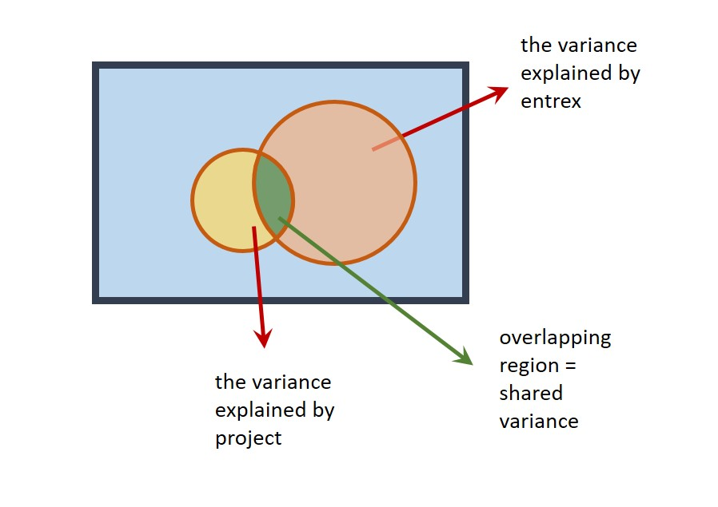

The correlation is represented as an overlap in the circles. Their total area (57.16%) is therefore *less* than the area they’d explain if there were no overlap (69.48%) (i.e., if there was no correlation).

**This demonstrates an important point**: The *t*-tests on the coefficients in a multiple regression assess the **unique** contribution of each predictor in the model. That is, they test the variance a predictor explains in an outcome variable, **after** the variance explained by the other predictors has been taken into account. This is why `project` is not statistically significant in the multiple regression model – it only explains a small amount of variance once `entrex` has been taken into account.

## 1.5 Multicollinearity

If the correlation between predictors is very high (greater than *r* = 0.9), this is known as **multicollinearity**. On a Venn diagram, the circles representing the predictors would almost completely overlap. Multicollinearity can be a problem in multiple regression. Predictors may explain a large amount of variance in the outcome variable, but their ‘unique’ contribution in a multiple regression may be small. A situation can arise where *neither* predictor may be statistically significant even though the overall regression is significant!

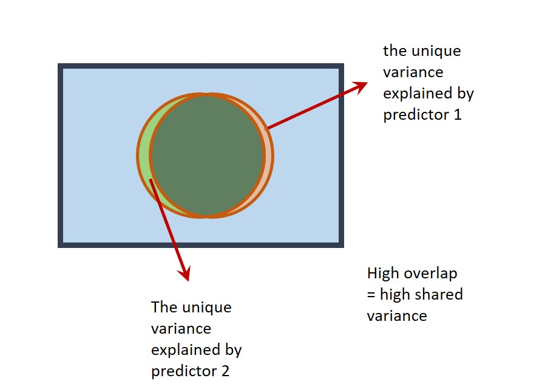

An example of multicollinearity in the `ExamData` dataset can be seen with the variables `project` and `proposal`.

Obtain the correlation between `project` and `proposal`:

```r
ExamData %>%
  select(project, proposal) %>%
  cor()
>            project  proposal
> project  1.0000000 0.9371487
> proposal 0.9371487 1.0000000
```

To see the effects of multicollinearity, conduct a regression with `finalex` as the outcome variable and `project` and `proposal` as the predictor variables.

```r
multi1 <- lm(finalex ~ project + proposal, data = ExamData)

summary(multi1)
>
> Call:
> lm(formula = finalex ~ project + proposal, data = ExamData)
>
> Residuals:
>     Min      1Q  Median      3Q     Max
> -64.287 -22.590  -0.346  22.395  70.289
>
> Coefficients:
>             Estimate Std. Error t value Pr(>|t|)
> (Intercept)   4.8784    40.8601   0.119    0.906
> project       1.2751     1.7072   0.747    0.461
> proposal      0.1826     1.7263   0.106    0.916
>
> Residual standard error: 30.81 on 30 degrees of freedom
> Multiple R-squared:  0.1641,  Adjusted R-squared:  0.1084
> F-statistic: 2.945 on 2 and 30 DF,  p-value: 0.06797
```

- How much variance in `finalex` is explained by the model: $R^2$ = %.
- Is the overall regression statistically significant?
- Is the coefficient for `project` statistically significant?
- Is the coefficient for `proposal` statistically significant?

Now run two simple regressions to determine whether `project` and `proposal` explain variance in `finalex` and are statistically significant predictors when in models on their own.

```r
multi2 <- lm(finalex ~ project, data = ExamData)
summary(multi2)
>
> Call:
> lm(formula = finalex ~ project, data = ExamData)
>
> Residuals:
>     Min      1Q  Median      3Q     Max
> -64.015 -21.686  -0.573  21.758  70.427
>
> Coefficients:
>             Estimate Std. Error t value Pr(>|t|)
> (Intercept)   4.6968    40.1677   0.117   0.9077
> project       1.4442     0.5861   2.464   0.0195 *
> ---
> Signif. codes:  0 '***' 0.001 '**' 0.01 '*' 0.05 '.' 0.1 ' ' 1
>
> Residual standard error: 30.32 on 31 degrees of freedom
> Multiple R-squared:  0.1638,  Adjusted R-squared:  0.1368
> F-statistic: 6.072 on 1 and 31 DF,  p-value: 0.01948

multi3 <- lm(finalex ~ proposal, data = ExamData)
summary(multi3)
>
> Call:
> lm(formula = finalex ~ proposal, data = ExamData)
>
> Residuals:
>     Min      1Q  Median      3Q     Max
> -64.987 -22.987  -1.378  24.059  68.921
>
> Coefficients:
>             Estimate Std. Error t value Pr(>|t|)
> (Intercept)   16.628     37.441   0.444   0.6601
> proposal       1.391      0.598   2.326   0.0267 *
> ---
> Signif. codes:  0 '***' 0.001 '**' 0.01 '*' 0.05 '.' 0.1 ' ' 1
>
> Residual standard error: 30.59 on 31 degrees of freedom
> Multiple R-squared:  0.1486,  Adjusted R-squared:  0.1211
> F-statistic: 5.409 on 1 and 31 DF,  p-value: 0.02675
```

- In a simple regression with `finalex` as the outcome variable, and `project` as the predictor variable, $R^2$ = %.
- Is the overall regression statistically significant?
- In a simple regression with `finalex` as the outcome variable, and `proposal` as the predictor variable, $R^2$ = %.
- Is the overall regression statistically significant?
- Try to explain what’s going on here in your own words. Click below or ask if you get stuck.

*Interpretation*

- Because `proposal` and `project` are highly correlated (*r* = 0.94), this gives rise to the situation where the simple regressions indicate that they explain variance in `finalex`, but when both are included as predictors in a multiple regression, it appears as if neither are significant predictors of `finalex` !
- If this were a real scenario, we’d consider dropping `project` or `proposal` from the model. Because the correlation is so high, having one predictor is as good as having the other (more or less).
- It seems intuitive that a person’s final project mark would be highly correlated with their proposal mark.
- The take-home message here is to check for high correlations between your predictor variables before including them in a multiple regression.

## 1.6 Final exercise

As a final exercise, run a multiple regression to predict `finalex` from **three** predictors: `entrex`, `project`, and `iq`.

```r
multi4 <- lm(finalex ~ entrex + project + iq, data = ExamData)

summary(multi4)
>
> Call:
> lm(formula = finalex ~ entrex + project + iq, data = ExamData)
>
> Residuals:
>     Min      1Q  Median      3Q     Max
> -40.444 -16.174   5.509  14.312  33.338
>
> Coefficients:
>              Estimate Std. Error t value Pr(>|t|)
> (Intercept) -130.3803    54.7288  -2.382 0.023981 *
> entrex         2.6180     0.5978   4.379 0.000142 ***
> project        0.6874     0.4490   1.531 0.136620
> iq             0.4862     0.4610   1.055 0.300214
> ---
> Signif. codes:  0 '***' 0.001 '**' 0.01 '*' 0.05 '.' 0.1 ' ' 1
>
> Residual standard error: 22.02 on 29 degrees of freedom
> Multiple R-squared:  0.5875,  Adjusted R-squared:  0.5448
> F-statistic: 13.77 on 3 and 29 DF,  p-value: 9.168e-06
```

Which variables are statistically significant predictors of `finalex`?

- `entrex`
- `project`
- `iq`

On the basis of all the models conducted so far (with `entrex`, `project`, and `iq`), which model would you choose to best predict `finalex`?

The model containing `entrex` alone, as this seems to provide the simplest and most effective model of the `finalex`.

A general goal of regression is to identify the fewest predictor variables necessary to predict an outcome variable, where each predictor variable predicts a substantial and independent segment of the variability in the outcome variable.

## 1.7 Summary of key points

- Predictors can be added to a model in `lm` using the `+` symbol
- e.g., `lm(finalex ~ entrex + project + iq)`
- Predictor variables are often correlated to some extent. This can affect the interpretation of individual predictor variables. Venn diagrams help to understand the results.
- The *F*-statistic tells us whether the model *as a whole* significantly predicts the outcome variable.
- The *t*-values tell us whether individual predictors in the model are statistically significant.
- In multiple regression, it’s important to understand that the statistical significance of individual predictors only holds **after taking into account the other predictors in the model**.
- **Multicollinearity** exists when predictors are very highly correlated (*r* above 0.9) and should be avoided.

# 2 Building models 2

*November 2020*

### 2.0.1 In brief

> In this session we discuss model selection in the context of ANOVA and the use of Bayes Factors to choose between theoretically interesting models.

## 2.1 Using ANOVA and Bayes Factors to compare models

- **Slides for the session**
- **Using Rmd files**

### 2.1.1 Overview

In the previous session, we saw that we can construct a linear model to predict an outcome variable (e.g., *final exam score* from *entrance exam score*). We also investigated how we can *improve* a model by adding several continuous predictors to it.

How do we know if one model is *better* or should be *preferred* over another model? We touched on a common sense approach in the last session - we ideally want models that explain the variance in an outcome variable but each predictor in the model should make a sizable and relatively independent contribution to the model.

Today we will cover a more formal approach to model comparison using:

- **ANOVA (Analysis of Variance)** and
- **Bayes Factors**

It’s important that you are comfortable with the material from the first Building Models 1 session before proceeding today.

## 2.2 Comparing models using ANOVA

We can use ANOVA to determine whether the addition of variables into a model leads to a statistically significant improvement in the variance it explains *overall*. We may want to do this, for example, when building on existing theories or models, or looking at the effects of variables after controlling for others.

We’ll start by comparing a model with *one* predictor vs. a model with *three* predictors.

Using the `ExamData` from the previous session, we’ll run:

- a linear model with `finalex` as the outcome variable, and `entrex` as the predictor.
- a linear model with `finalex` as the outcome variable, and `entrex`,`age`, and `project` as the predictors.

```r
ExamData <- read_csv('https://bit.ly/37GkvJg')
model1   <- lm(finalex ~ entrex, data = ExamData)
model2   <- lm(finalex ~ entrex + age + project, data = ExamData)
```

**Explanation of the code**: first the data is loaded into `ExamData`. The results of the simple regression are stored in `model1`. Those of the multiple regression are stored in `model2`.

Use `summary()` to display the results of each regression:

**Model 1:**

```r
summary(model1)
>
> Call:
> lm(formula = finalex ~ entrex, data = ExamData)
>
> Residuals:
>     Min      1Q  Median      3Q     Max
> -54.494 -21.185   3.733  18.124  30.969
>
> Coefficients:
>             Estimate Std. Error t value Pr(>|t|)
> (Intercept) -46.3045    25.4773  -1.817   0.0788 .
> entrex        3.1545     0.5324   5.925 1.52e-06 ***
> ---
> Signif. codes:  0 '***' 0.001 '**' 0.01 '*' 0.05 '.' 0.1 ' ' 1
>
> Residual standard error: 22.7 on 31 degrees of freedom
> Multiple R-squared:  0.531,   Adjusted R-squared:  0.5159
> F-statistic:  35.1 on 1 and 31 DF,  p-value: 1.52e-06
```

**Model 2:**

```r
summary(model2)
>
> Call:
> lm(formula = finalex ~ entrex + age + project, data = ExamData)
>
> Residuals:
>     Min      1Q  Median      3Q     Max
> -42.563 -16.519   4.901  16.991  36.424
>
> Coefficients:
>              Estimate Std. Error t value Pr(>|t|)
> (Intercept) -117.9159    46.4211  -2.540   0.0167 *
> entrex         3.0889     0.5734   5.387 8.66e-06 ***
> age            1.4231     1.3756   1.035   0.3094
> project        0.6280     0.4609   1.363   0.1835
> ---
> Signif. codes:  0 '***' 0.001 '**' 0.01 '*' 0.05 '.' 0.1 ' ' 1
>
> Residual standard error: 22.03 on 29 degrees of freedom
> Multiple R-squared:  0.5869,  Adjusted R-squared:  0.5442
> F-statistic: 13.73 on 3 and 29 DF,  p-value: 9.353e-06
```

(If you are not sure what it means by “e-06” in the output above then see the FAQs here)

Make note of the variance explained by each model ($R^2$), i.e., `Multiple R-squared`: (report as a percentage, to 2 decimal places)

- Model 1: $R^2$ = %
- Model 2: $R^2$ = %

Which model explains a greater proportion of variance in `finalex`?

- Calculate the difference in $R^2$ between the models. `model2` improves the prediction of `finalex` by %

To compare the variance explained by each model, use `anova()`:

```r
anova(model1, model2)
> Analysis of Variance Table
>
> Model 1: finalex ~ entrex
> Model 2: finalex ~ entrex + age + project
>   Res.Df   RSS Df Sum of Sq      F Pr(>F)
> 1     31 15981
> 2     29 14078  2      1903 1.9601 0.1591
```

**Explanation of the output:**

- **`anova()`** compares the variance that `model1` and `model2` explain with an *F*-statistic.
- **`Pr(>F)`** gives the *p*-value for this statistic. If the *p*-value is less than .05, then we can reject the null hypothesis that there is no difference in the variance explained by each model, and we can say that the variance that `model2` explains in `finalex` is significantly greater than that of `model1`.
- We can report the *F*-statistic in APA style as *F*(2, 29) = 1.96, *p* = .16. We can say that the additional 5.59% variance that `model2` explains relative to `model1` does not represent a statistically significant increase in $R^2$, and so `model2` should **not** be preferred over `model1`.

Comparing models in steps as we’ve done is sometimes called **hierarchical regression** or **sequential regression**. This type of regression is usually used for logical or theoretical reasons, when we want to know the contribution of a predictor (or a set of predictors) **over and above** an existing one.

**Now, you try using `anova` to compare models.**

The variable `attendance` in `ExamData` scores individuals according to whether their class attendance was low (0) or high (1). A researcher suspects that `attendance` may explain additional variance in `finalex` over and above `entrex`.

As an exercise, compare the following two models using the `anova()` approach above:

1. a model with `entrex` as a sole predictor of `finalex` (i.e., `model1`), and
2. a model where `finalex` is predicted by `entrex` and `attendance` (call this `model3`).

Is there sufficient evidence that a model with `entrex` *and* `attendance` explains more variance than a model with `entrex` alone?

```r
# model1 was created earlier
summary(model1)
>
> Call:
> lm(formula = finalex ~ entrex, data = ExamData)
>
> Residuals:
>     Min      1Q  Median      3Q     Max
> -54.494 -21.185   3.733  18.124  30.969
>
> Coefficients:
>             Estimate Std. Error t value Pr(>|t|)
> (Intercept) -46.3045    25.4773  -1.817   0.0788 .
> entrex        3.1545     0.5324   5.925 1.52e-06 ***
> ---
> Signif. codes:  0 '***' 0.001 '**' 0.01 '*' 0.05 '.' 0.1 ' ' 1
>
> Residual standard error: 22.7 on 31 degrees of freedom
> Multiple R-squared:  0.531,   Adjusted R-squared:  0.5159
> F-statistic:  35.1 on 1 and 31 DF,  p-value: 1.52e-06

# specify model3
model3 <- lm(finalex ~ entrex + attendance, data = ExamData)

# show model3
summary(model3)
>
> Call:
> lm(formula = finalex ~ entrex + attendance, data = ExamData)
>
> Residuals:
>     Min      1Q  Median      3Q     Max
> -42.750 -11.750   1.801   9.689  30.347
>
> Coefficients:
>             Estimate Std. Error t value Pr(>|t|)
> (Intercept) -63.3108    20.2768  -3.122  0.00395 **
> entrex        3.2741     0.4173   7.846 9.35e-09 ***
> attendance   28.8202     6.3398   4.546 8.37e-05 ***
> ---
> Signif. codes:  0 '***' 0.001 '**' 0.01 '*' 0.05 '.' 0.1 ' ' 1
>
> Residual standard error: 17.76 on 30 degrees of freedom
> Multiple R-squared:  0.7223,  Adjusted R-squared:  0.7038
> F-statistic: 39.02 on 2 and 30 DF,  p-value: 4.499e-09

#compare model1 and model3
anova(model1, model3)
> Analysis of Variance Table
>
> Model 1: finalex ~ entrex
> Model 2: finalex ~ entrex + attendance
>   Res.Df     RSS Df Sum of Sq      F   Pr(>F)
> 1     31 15980.6
> 2     30  9462.4  1    6518.1 20.665 8.37e-05 ***
> ---
> Signif. codes:  0 '***' 0.001 '**' 0.01 '*' 0.05 '.' 0.1 ' ' 1
```

- The variance explained by a model with `entrex` alone is $R^2$ = %
- The $R^2$ for the model that also included `attendance` was $R^2$ = %
- The increase in $R^2$ was %
- The ANOVA comparing models can be reported as: *F*(, ) = , *p* < .001.
- The increase in $R^2$ was .
- As indicated by the estimates of the coefficients for `entrex` and `attendance`, both predict `finalex`.
- A higher `entrex` score and greater `attendance` is associated with a `finalex` score.

## 2.3 Comparing models using Bayes Factors

An alternative approach to using ANOVA to compare models is to use **Bayes Factors**.

A **Bayes Factor** is the **probability of obtaining the data under one model compared to another** (Rouder & Morey, 2012).

For example, a Bayes Factor equal to 2 would tell us that the data are *twice* as likely under one model than another. A Bayes Factor equal to 0.5 would tell us that the data are *half* as likely under one model than another.

Unlike classical tests of statistical significance (with *p*-values), Bayes Factors also allow us to *quantify* evidence for the null hypothesis. Very handy!

To compute a Bayes Factor for a specific linear model, we use `lmBF` in the `BayesFactor` package (where `lm` stands for *linear model* and `BF` stands for *Bayes Factor*).

First, we need to load the `BayesFactor` package:

```r
library('BayesFactor')
```

We can use the `lmBF` function in the same way we use `lm`. The function will return a **Bayes Factor** for the model we specify.

Let’s determine the Bayes Factor for `model1`

```r
model1.BF <- lmBF(finalex ~ entrex, data = as.data.frame(ExamData) )
```

**Explanation of the code**: The model is specified in exactly the same way as with `lm`. Due to a limitation of the package, however, we must convert `ExamData` from a tibble to a data frame using `as.data.frame`. Otherwise, the command works in the same way. The results are stored in `model1.BF`.

To look at what’s stored in `model1.BF`:

```r
model1.BF
> Bayes factor analysis
> --------------
> [1] entrex : 8310.846 ±0.01%
>
> Against denominator:
>   Intercept only
> ---
> Bayes factor type: BFlinearModel, JZS
```

Now let’s do the same for `model2`:

```r
# specify the model
model2.BF <- lmBF(finalex ~ entrex + age + project, data = as.data.frame(ExamData) )

# show the Bayes Factor
model2.BF
> Bayes factor analysis
> --------------
> [1] entrex + age + project : 2427.676 ±0%
>
> Against denominator:
>   Intercept only
> ---
> Bayes factor type: BFlinearModel, JZS
```

```r
model2.BF / model1.BF
> Bayes factor analysis
> --------------
> [1] entrex + age + project : 0.2921093 ±0.01%
>
> Against denominator:
>   finalex ~ entrex
> ---
> Bayes factor type: BFlinearModel, JZS
```

**Explanation:** The Bayes Factor for this comparison is 0.29. This means that `model2` is *less than a third as likely* than `model1`. So, `model2` is much *less* likely than `model1`. Not good news for `model2`!

**Interpreting the Bayes Factor**

- A Bayes Factor **equal to 1** tells us that probability of each model is the same.
- A Bayes Factor **greater than 1** means that `model2` is more likely than `model1`.
- A Bayes Factor **less than 1** means that `model1` is more likely than `model2`.

**Thus, our Bayes Factor of 0.29 indicates that `model1` is more likely than `model2`.**

**Reporting Bayes Factors**

**Notation**

We usually write the Bayes Factor in reports as $BF_{10}$ where:

- the subscript **1** in $BF_{10}$ denotes the less-constrained model (the alternative hypothesis). This is the model with **more predictors** (our `model2`).
- the subscript **0** in $BF_{10}$ denotes the more constrained or simpler model (i.e., the null hypothesis). This is the model with **fewer predictors** (our `model1`).

(You can just write BF10 if you prefer.)

**The Size of the Bayes Factor**

- If the Bayes Factor is **greater than 3** (i.e., $BF_{10}$ > 3), we say that there is **substantial evidence for `model2`** (the less constrained model).
- If the Bayes Factor is **less than 0.33** (i.e., $BF_{10}$ < 0.33), we usually say that there is **substantial evidence for `model1`** (the more constrained model).
- We say that intermediate values for the Bayes Factor (between 0.33 and 3) don’t offer strong evidence for either model.

Thus, because our Bayes Factor of 0.29 is less than 1, this indicates greater evidence for `model1` than `model2`. Furthermore, because the Bayes Factor is less than 0.33, we have *substantial* evidence for `model1` over `model2`.

It’s becoming increasingly common to report the Bayes Factor alongside the results of a classical analysis. Thus, we could report our results as follows: “There was insufficient evidence that the addition of age and project to the model containing entrance exam resulted in an increase in $R^2$, *F*(2, 29) = 1.96, *p* = .16; BF10 = 0.29.”

**Now you try using Bayes Factors to compare models**

To supplement the comparison of `model3` and `model1` that you did with `anova`, now compute the Bayes Factor for `model3` vs. `model1`.

You’ll need the following steps:

- Model 1: Obtain the Bayes Factor for a model with `entrex` as a sole predictor of `finalex` (we did this already above; it’s stored in `model1.BF`)
- Model 2: Obtain the Bayes Factor for a model where `finalex` is predicted by `entrex` *and* `attendance` and store this in `model3.BF`.
- Compare the Bayes Factors in `model3.BF` and `model1.BF`.

```r
# 1. show the BF for model1 vs. intercept only
model1.BF
> Bayes factor analysis
> --------------
> [1] entrex : 8310.846 ±0.01%
>
> Against denominator:
>   Intercept only
> ---
> Bayes factor type: BFlinearModel, JZS

# 2. Obtain the BF for model3 vs. intercept only, then show it
model3.BF <- lmBF(finalex ~ entrex + attendance, data = as.data.frame(ExamData) )

model3.BF
> Bayes factor analysis
> --------------
> [1] entrex + attendance : 2351114 ±0%
>
> Against denominator:
>   Intercept only
> ---
> Bayes factor type: BFlinearModel, JZS

# 3. Compare the BFs for model3 vs model1
model3.BF / model1.BF
> Bayes factor analysis
> --------------
> [1] entrex + attendance : 282.897 ±0.01%
>
> Against denominator:
>   finalex ~ entrex
> ---
> Bayes factor type: BFlinearModel, JZS
```

**Answer the following questions from the output:**

How much more likely is a model with`entrex` than an intercept only model?

- times more likely.

How much more likely is a model with `entrex` and `attendance` than an intercept only model?

- times more likely.

How much more likely is a model with `entrex` and `attendance` as predictors than a model with `entrex` alone?

- times more likely.

There is evidence that a model with `entrex` and `attendance` should be preferred over a model with `entrex` alone, given the data.

## 2.4 Exercise

Now you will practise using ANOVA and Bayes Factors to compare models with a new dataset.

**Scenario:** A researcher would like to construct a model to predict scores in a memory task from several different variables. The data from 234 individuals are stored in the `memory_data` dataset, which are located at https://bit.ly/37pOTrC.

Use `read_csv` to load in the data at the link above to the variable `memory_data` and preview it with `head()`.

```r
memory_data <- read_csv('https://bit.ly/37pOTrC')
memory_data %>% head()
> # A tibble: 6 x 7
>   attention   sex blueberries    iq   age sleep memory_score
>       <dbl> <dbl>       <dbl> <dbl> <dbl> <dbl>        <dbl>
> 1      95.8     1         308  99.9  44.9  9.94        128.
> 2      66.7     1         270 137.   29.4  8.04        127.
> 3     102.      1         442 110.   31.9 11.0         118.
> 4      36.9     1         219 110.   27.9  5.28         95.5
> 5      91.7     0         450 119.   36.7  9.30        122.
> 6     146.      1         255  85.6  23.9  7.05        102.
```

**About the data:**

- **attention**: sustained attention score (higher = better attention)
- **sex**: 0 = female, 1 = male
- **blueberries**: average number of blueberries consumed per year
- **iq**: the individual’s IQ
- **age**: age of person in years
- **sleep**: average hours of sleep per night
- **memory_score**: memory test score

The researcher wants to test whether `attention` and `sleep` predict `memory_score`, but after controlling for `iq` and `age` (she suspects memory varies with `iq` and `age` to being with).

She therefore wants to use a hierarchical regression approach to determine whether `attention` and `sleep` explain additional variance in `memory_score` *over and above* `iq` and `age`.

1. First, fit a linear model to determine the extent to which `memory_score` is predicted by `iq` and `age`. Store the results in `memory1`.

```r
# specify the baseline model
memory1 <- lm(memory_score ~ iq + age, data = memory_data)

# see the model results
summary(memory1)
>
> Call:
> lm(formula = memory_score ~ iq + age, data = memory_data)
>
> Residuals:
>     Min      1Q  Median      3Q     Max
> -44.154 -11.754   0.732  11.608  40.790
>
> Coefficients:
>             Estimate Std. Error t value Pr(>|t|)
> (Intercept)  71.1669     9.0796   7.838 1.67e-13 ***
> iq            0.1073     0.0699   1.534    0.126
> age           0.8220     0.1461   5.627 5.27e-08 ***
> ---
> Signif. codes:  0 '***' 0.001 '**' 0.01 '*' 0.05 '.' 0.1 ' ' 1
>
> Residual standard error: 16.1 on 231 degrees of freedom
> Multiple R-squared:  0.1303,  Adjusted R-squared:  0.1228
> F-statistic: 17.31 on 2 and 231 DF,  p-value: 9.875e-08
```

2. Next, add `attention` and `sleep` to the model, storing your results in `memory2`.

```r
# specify the next model
memory2 <- lm(memory_score ~ iq + age + attention + sleep, data = memory_data)

# show the results
summary(memory2)
>
> Call:
> lm(formula = memory_score ~ iq + age + attention + sleep, data = memory_data)
>
> Residuals:
>     Min      1Q  Median      3Q     Max
> -28.935  -8.555   1.713   8.450  31.384
>
> Coefficients:
>             Estimate Std. Error t value Pr(>|t|)
> (Intercept)  9.60112    8.57889   1.119 0.264246
> iq           0.18673    0.05451   3.426 0.000726 ***
> age          0.86579    0.11308   7.656 5.32e-13 ***
> attention    0.22894    0.02757   8.302 8.88e-15 ***
> sleep        3.68609    0.39328   9.373  < 2e-16 ***
> ---
> Signif. codes:  0 '***' 0.001 '**' 0.01 '*' 0.05 '.' 0.1 ' ' 1
>
> Residual standard error: 12.46 on 229 degrees of freedom
> Multiple R-squared:  0.4839,  Adjusted R-squared:  0.4749
> F-statistic: 53.68 on 4 and 229 DF,  p-value: < 2.2e-16
```

3. Now, compare the `memory1` and `memory2` models using `anova()`

```r
anova(memory1, memory2)
> Analysis of Variance Table
>
> Model 1: memory_score ~ iq + age
> Model 2: memory_score ~ iq + age + attention + sleep
>   Res.Df   RSS Df Sum of Sq      F    Pr(>F)
> 1    231 59912
> 2    229 35554  2     24359 78.447 < 2.2e-16 ***
> ---
> Signif. codes:  0 '***' 0.001 '**' 0.01 '*' 0.05 '.' 0.1 ' ' 1
```

**Answer the following questions:**

- A model with `iq` and `age` as predictors explains % of the variance in `memory_scores`
- A model with `iq`, `age`, `attention` and `sleep` as predictors explains % of the variance in `memory_scores`
- Calculate the additional variance explained by the second model: Change in $R^2$ = %
- The ANOVA comparing models can be reported as: *F*(, ) = , *p* < .001.
- Is there a statistically significant improvement in the prediction of `memory_scores` as a result of adding `attention` and `sleep` to the model?

**Now use Bayes Factors to determine how much more likely the `memory2` model is than the `memory1` model .**

- Determine the Bayes Factor for `memory1`
- Determine the Bayes Factor for `memory2`
- Compare the Bayes Factors for `memory2` and `memory1`

```r
# Store the Bayes Factor for the first model in memory1.BF
memory1.BF <- lmBF(memory_score ~ iq + age, data = as.data.frame(memory_data) )

# Store the Bayes Factor for the second model in memory2.BF
memory2.BF <- lmBF(memory_score ~ iq + age + attention + sleep, data = as.data.frame(memory_data) )

# Compute the Bayes Factors for memory2.BF vs memory1.BF
memory2.BF / memory1.BF
> Bayes factor analysis
> --------------
> [1] iq + age + attention + sleep : 4.168455e+23 ±0%
>
> Against denominator:
>   memory_score ~ iq + age
> ---
> Bayes factor type: BFlinearModel, JZS
```

**Answer the following questions:**

- The Bayes Factor comparing `memory2` and `memory1` to (2 decimal places) is e+ .
- Does the Bayes Factor support the conclusions from the ANOVA?

Yes! The Bayes Factor is equal to $4.17 \times 10^{23}$, and this therefore strongly supports the inclusion of `attention` and `sleep` in the model already containing `iq` and `age`.

**Extra exercises, if there’s time**

**1.**

The researcher wishes to predict the `memory_score` for a new individual with `iq` = 105, `age` = 27, `attention` = 90, `sleep` = 8. Determine the prediction.

Hint: in a previous session, you have previously used the `predict()` function to do this.

- The predicted `memory_score` is

```r
# create tibble for the new data
new_data <- tibble(iq = 105, age = 27, attention = 90, sleep = 8)

# use predict to derive prediction from new data
predict(memory2, new_data)
>        1
> 102.6768
```

**2.** Create a scatterplot of `attention` against `memory_score`, with the size of each point indicating the hours of `sleep`

[figure not shown]

```r
memory_data %>%
  ggplot(aes(x = attention, y = memory_score, size = sleep)) +
  geom_point(alpha = 0.5) +   # alpha=0.5 makes points 50% transparent
  xlab('Memory Score') +
  ylab('Attention Score') +
  labs(size="Sleep (hours)")
```

**3.**

The researcher is interested to know whether annual consumption of blueberries has any bearing on `memory_scores`, and so wants to add `blueberries` to the model in `memory2`.

Determine the Bayes Factor comparing `memory2` with a model that additionally contains `blueberries`.

- The Bayes Factor for the model comparison is (to 2 decimal places)
- The Bayes Factor indicates that the model with `blueberries` is than the model without it.
- Should the researcher add `blueberries` to the model?

```r
# add blueberries to memory2; store in memory3.BF
memory3.BF <- lmBF(memory_score ~ iq + age + attention + sleep + blueberries, data = as.data.frame(memory_data) )

# calculate the BF for memory3 vs memory2
memory3.BF / memory2.BF
> Bayes factor analysis
> --------------
> [1] iq + age + attention + sleep + blueberries : 0.1663574 ±0%
>
> Against denominator:
>   memory_score ~ iq + age + attention + sleep
> ---
> Bayes factor type: BFlinearModel, JZS
```

## 2.5 Summary of key points

- We can compare a model with one that has more predictors by using `anova(model1, model2)`.
- We can compare models using Bayes Factors with `lmBF` in the `BayesFactor` package.
- A **Bayes Factor** is probability of one model relative to another, *given the data*.
- To compare Bayes Factors of models:
  - First obtain the Bayes Factors for `model1` and `model2`.
  - Then use `model2 / model1` to get the Bayes Factor, indicating how much more likely `model2` is.
- Bayes Factors less than 1 indicate evidence for `model1`
- Bayes Factors greater than 1 indicate evidence for `model2`
- We can report Bayes Factors as $BF_{10}$ = 2.23 (or BF10 = 2.23)

Next week’s session will build on what was done in this session, so make sure you understand what was covered and ask if there’s anything you’re unsure of.

# 3 Fitting curves

*November 2020*

### 3.0.1 In brief

> So far all our regression models have assumed that our variables have *linear relationships*. That isn’t always the case, and sometimes we need to fit curved lines to describe the relationship of predictors and outcomes. As we saw before, fitting curved lines has costs as well as benefits: A curved line is more likely to **overfit** the data, and may be less good at predicting new data. But for some models curved lines are essential to describe the world as it really is.

## 3.1 Using polynomials to fit curves

- **Slides for the session**

### 3.1.1 Overview

In this session we will:

- See how we can add *polynomial terms* such as $x^2$, $x^3$ to a regression model to capture non-linear relationships.
- Use ANOVA and Bayes Factors to determine whether these terms improve the model.

You should be comfortable with what we did in the previous **Building Models 1** and **Building Models 2** sessions before attempting this one.

## 3.2 Polynomials

The regression models we have been fitting assume a **linear** (i.e., straight line) relationship between variables. However, variables may not always be related in a linear fashion.

Suppose variables x and y showed the following trend:

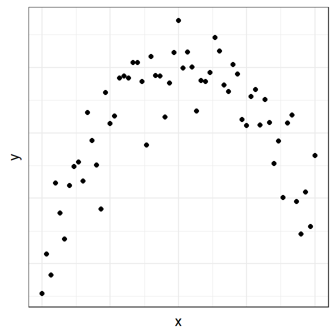

Values of y increase with x up to a point, then decrease again. It is clear that this relationship would not be explained well by a straight line. We’d lose important information about the relationship if we only fit a straight line. A curve would be better.

We can fit a curve to the data by adding **polynomial** terms to the regression equation.

**Polynomial** means that a variable is raised to a particular power. For example:

- $x^2$ means x-squared, which is x-multiplied-by-x, or “x to the power of two”
- $x^3$ means x-cubed, which is x-multiplied-by-x-multiplied-by-x, or “x to the power of three”

If a model has a **quadratic component** it means it has an $x^2$ term in the equation.

If a model has a **cubic component** it means it has an $x^3$ term in the equation.

To see why this approach works, recall that lines can be represented by equations.

### 3.2.1 Components of a regression line

The equation **$y = 1 + 0.5x$** would be represented as follows:

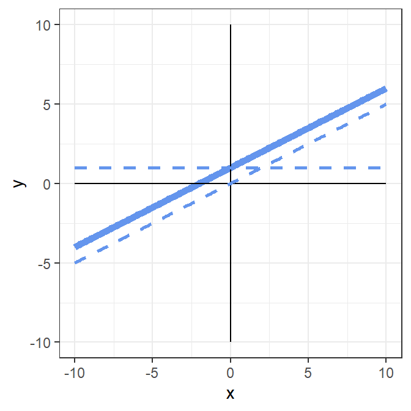

We can think of this line as being made up of the **constant** and a **linear** component.

- The **constant** in this equation is indicated by the dashed horizontal line.
- The **linear** component to this equation 0.5x is indicated by the dashed slope line.
- The solid blue line is a *combination* of these two components.

### 3.2.2 Quadratic

The equation **$y = x^2$** would be represented as follows:

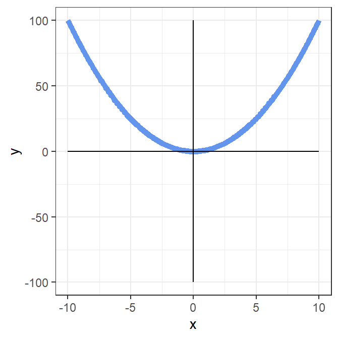

To get each value of y, we square the value of x.

So, when x = -5, y is 25.

And if x = -4, y = 16, and so on…

**$y = -x^2$**, would look as follows:

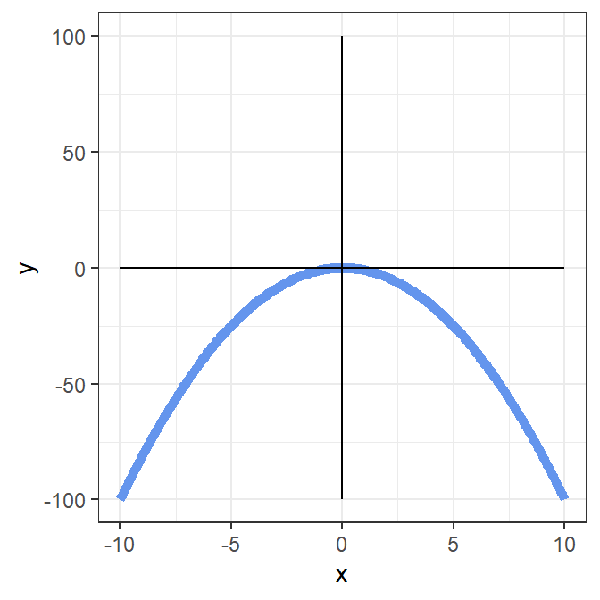

Curves with quadratic components have **one bend**.

### 3.2.3 Cubic

The equation **$y = x^3$** would be represented as follows:

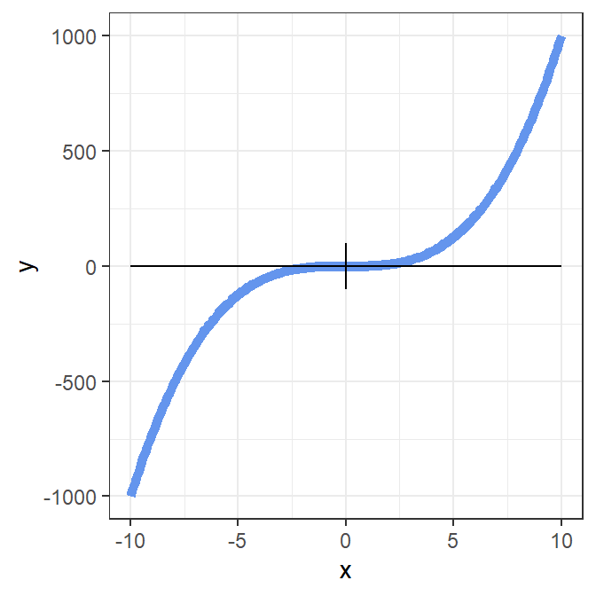

To get each value of y, we *cube* the value of x.

So, when x = -5, y is -125.

And if x = 10, y = 1000, and so on…

**$y = -x^3$**, would look as follows:

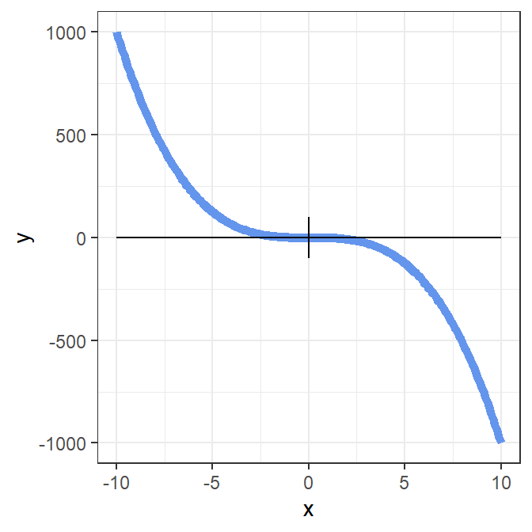

Curves with cubic components have **two bends**.

### 3.2.4 Linear plus quadratic components

The equation **$y = 50 + 5x - x^2$** has

- a constant equal to **50**
- a linear component **5x**
- a quadratic component **$-x^2$**:

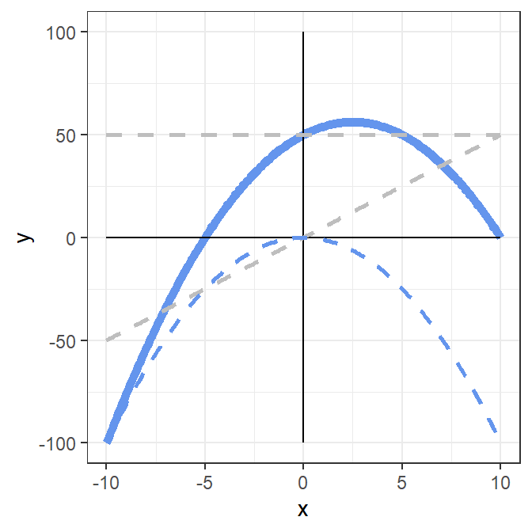

The dashed lines on the plot indicate the *intercept*, *linear component*, and *quadratic component* of the equation. The solid line represents the equation.

### 3.2.5 Linear + quadratic + cubic components

The equation **$y = 5000 + 750x - 50x^2 - 20x^3$** has

- a constant equal to **5000**
- a linear component **750x**
- a negative quadratic component **$-50x^2$**
- a negative cubic component **$-20x^3$**

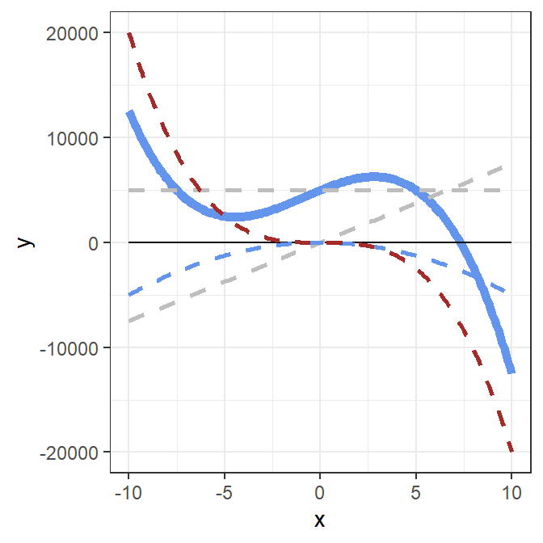

The dashed lines in the plot indicate the different components of the curve indicated by the solid blue line.

When we see any curve, it is possible to think of it as being composed of components like this. In theory, we can keep adding components, but it’s rare to see greater higher-order components (e.g., $x^4$) being added because issues of overfitting and generalisability can arise (mentioned in the slides).

## 3.3 Identifying polynomial components

To determine whether a model should have quadratic, cubic, or higher order components, we can use the **sequential regression** approach covered in the previous session. We take the following steps, and look at the change in $R^2$ associated with each step.

- First fit the **linear** model
- then test for the *addition* of the **quadratic ($x^2$)** component
- then test for the *addition* of the **cubic ($x^3$)** component

Let’s see this in action!

**Learning tip**

Try storing all your code in an **R Markdown** file today if you are not doing so already! You can use code chunks and write text to describe each chunk as was described in the slides.

We’ll use a dataset inspired by a 2016 survey of the National Office for Statistics. They investigated happiness across the life span. Approximately 300,000 individuals of all ages answered questions related to well-being.

Each participant answered the following question regarding their *happiness*:

**"Overall, how happy did you feel yesterday?**  
**Where 0 is ‘not at all happy’ and 10 is ‘completely happy’."**

This `happy` dataset is located at https://bit.ly/2uIxM5K

Load the data into R, and preview the data using `head`:

```r
# load the data
SurveyData <- read_csv("https://bit.ly/2uIxM5K")

# preview it
SurveyData %>% head()
> # A tibble: 6 x 3
>     age happiness anxiety
>   <dbl>     <dbl>   <dbl>
> 1  66.0      7.85    2.33
> 2  35.0      7.56    2.58
> 3  58.6      7.59    3.43
> 4  35.0      7.06    1.67
> 5  60.2      7.96    2.13
> 6  67.5      8.11    1.09
```

Plot the relationship between `age` and `happiness`:

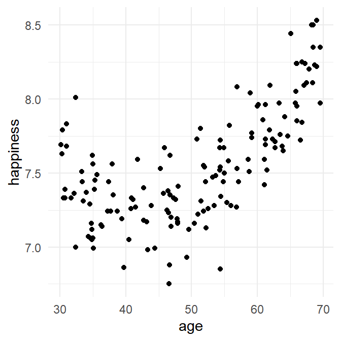

```r
SurveyData %>%
  ggplot(aes(x = age, y = happiness)) +
  geom_point()
```

If you had to guess from the plot, which components seem to be present in the relationship between `happiness` and `age`?

Linear:

Quadratic:

Cubic:

Describe the relationship between `happiness` and `age` (look at the figure and describe the trend in words).

Happiness of individuals appears to decline from 30 years to the late forties. Happiness then increases beyond the late forties, reaching its peak at 70 years, at which age people reported the highest levels of happiness - higher even than levels shown in early thirties.

### 3.3.1 Linear component

To determine whether there is a linear component, run a simple regression with `happiness` as the outcome variable and `age` as the predictor. Store the result in `polynomial1`:

```r
polynomial1 <- lm(happiness ~ age, data = SurveyData)
summary(polynomial1)
>
> Call:
> lm(formula = happiness ~ age, data = SurveyData)
>
> Residuals:
>      Min       1Q   Median       3Q      Max
> -0.78019 -0.16858 -0.04762  0.19811  0.84368
>
> Coefficients:
>             Estimate Std. Error t value Pr(>|t|)
> (Intercept) 6.484101   0.102340   63.36   <2e-16 ***
> age         0.021076   0.001979   10.65   <2e-16 ***
> ---
> Signif. codes:  0 '***' 0.001 '**' 0.01 '*' 0.05 '.' 0.1 ' ' 1
>
> Residual standard error: 0.2912 on 148 degrees of freedom
> Multiple R-squared:  0.4339,  Adjusted R-squared:  0.4301
> F-statistic: 113.5 on 1 and 148 DF,  p-value: < 2.2e-16
```

**Explanation:** The linear model is stored in `polynomial1`. `summary` displays the results.

What percentage of the variance in `happiness` scores is explained by `age`? %

Is `age` a statistically significant predictor of `happiness`

The linear model explains a statistically significant portion of the data, but remember it is only fitting a straight line through our data, which appear to show a curved relationship!

### 3.3.2 Adding a quadratic component

We can add a quadratic component to the regression model using `poly()`.

If we type `poly(age, 2)` when specifying the model, the ‘2’ in the `poly()` function tells R that we want to fit a model with **both** linear and quadratic components of `age`. This is the model it will fit:

$predicted \: happiness = a + b_1(age) + b_2(age^2)$

where $a$ is the intercept, and $b_1$ and $b_2$ are the coefficients for the linear and quadratic components, respectively.

```r
polynomial2 <- lm(happiness ~ poly(age,2), data = SurveyData)

summary(polynomial2)
>
> Call:
> lm(formula = happiness ~ poly(age, 2), data = SurveyData)
>
> Residuals:
>      Min       1Q   Median       3Q      Max
> -0.58896 -0.12752 -0.02333  0.13274  0.59724
>
> Coefficients:
>               Estimate Std. Error t value Pr(>|t|)
> (Intercept)    7.54433    0.01779  424.06   <2e-16 ***
> poly(age, 2)1  3.10223    0.21789   14.24   <2e-16 ***
> poly(age, 2)2  2.36118    0.21789   10.84   <2e-16 ***
> ---
> Signif. codes:  0 '***' 0.001 '**' 0.01 '*' 0.05 '.' 0.1 ' ' 1
>
> Residual standard error: 0.2179 on 147 degrees of freedom
> Multiple R-squared:  0.6853,  Adjusted R-squared:  0.681
> F-statistic: 160.1 on 2 and 147 DF,  p-value: < 2.2e-16
```

**Explanation of the code:** We’ve told R we want to add a quadratic component to the model by using `happiness ~ poly(age, 2)`.

**Explanation of the output:** You will see in the output separate coefficient estimates for `poly(age, 2)1` and `poly(age, 2)`. These are the estimates of the coefficients for the linear and quadratic components of `age` (i.e., $b_1$ and $b_2$ in the equation above).

What percentage of the variance in `happiness` does a model with a **quadratic component** of `age` explain? %

Compare the value of $R^2$ in `polynomial1` and `polynomial2`.

- Does the addition of a quadratic component result in a numerical increase in $R^2$ in `polynomial2`?
- What is the change in $R^2$? % (to 2 decimal places)

$R^2$ change from `polynomial1` to `polynomial2` = 68.53 - 43.39 = 25.14%

Therefore, the model with the quadratic component of `age` accounts for **25.14% more variance** in `happiness` than the model with only a linear component.

We can test whether the *increase* in *R*<sup>2</sup> in `polynomial2` represents a statistically significant increase by comparing `polynomial1` and `polynomial2` using `anova`:

```r
anova(polynomial1, polynomial2)
> Analysis of Variance Table
>
> Model 1: happiness ~ age
> Model 2: happiness ~ poly(age, 2)
>   Res.Df     RSS Df Sum of Sq      F    Pr(>F)
> 1    148 12.5542
> 2    147  6.9791  1    5.5752 117.43 < 2.2e-16 ***
> ---
> Signif. codes:  0 '***' 0.001 '**' 0.01 '*' 0.05 '.' 0.1 ' ' 1
```

Is the increase in $R^2$ associated with the addition of the quadratic component statistically significant?

Yes. We can report the improvement in fit as follows:

A model with a quadratic component of `age` accounted for a statistically significantly greater proportion of variance in `happiness` than a model with only a linear component, *F*(1, 147) = 117.43, *p* < .001.

### 3.3.3 Adding a cubic component

Now we’ll test for a cubic component:

```r
polynomial3 <- lm(happiness ~ poly(age,3), data = SurveyData)
summary(polynomial3)
>
> Call:
> lm(formula = happiness ~ poly(age, 3), data = SurveyData)
>
> Residuals:
>      Min       1Q   Median       3Q      Max
> -0.60468 -0.14165 -0.01844  0.13839  0.58176
>
> Coefficients:
>               Estimate Std. Error t value Pr(>|t|)
> (Intercept)    7.54433    0.01777 424.447   <2e-16 ***
> poly(age, 3)1  3.10223    0.21769  14.251   <2e-16 ***
> poly(age, 3)2  2.36118    0.21769  10.846   <2e-16 ***
> poly(age, 3)3 -0.24530    0.21769  -1.127    0.262
> ---
> Signif. codes:  0 '***' 0.001 '**' 0.01 '*' 0.05 '.' 0.1 ' ' 1
>
> Residual standard error: 0.2177 on 146 degrees of freedom
> Multiple R-squared:  0.688,   Adjusted R-squared:  0.6816
> F-statistic: 107.3 on 3 and 146 DF,  p-value: < 2.2e-16
```

The ‘3’ in `poly(age,3)` tells R that we want to specify a model with linear, quadratic *and* cubic components, of the form:

$happiness = a + b_1(age) + b_2(age^2) + b_3(age^3)$

What percentage of the variance in `happiness` does a model with a **cubic component** of `age` explain? %

Compare the value of $R^2$ in `polynomial3` and `polynomial2`.

- Does the addition of a cubic component result in a numerical increase in $R^2$ in `polynomial3`?
- What is the increase in $R^2$ as a result of adding in the cubic component? (Compare $R^2$ between `polynomial3` and `polynomial2`).

  The increase in $R^2$ is %

To determine if the increase in $R^2$ is statistically significant, we can again use `anova`:

```r
anova(polynomial2, polynomial3)
> Analysis of Variance Table
>
> Model 1: happiness ~ poly(age, 2)
> Model 2: happiness ~ poly(age, 3)
>   Res.Df    RSS Df Sum of Sq      F Pr(>F)
> 1    147 6.9791
> 2    146 6.9189  1  0.060171 1.2697 0.2617
```

Is the increase in $R^2$ associated with the addition of a cubic component statistically significant?

The `anova` comparing `polynomial3` and `polynomial2` is not statistically significant, *F*(1, 146) = 1.27, *p* = .26, indicating that the addition of the cubic component of `age` into the regression model does not increase the variance in `happiness` explained.

On the basis of the tests conducted so far, which model should be preferred? One with:

Our analyses suggest that a model with a quadratic component of `age` (i.e., the model in `polynomial2`) is sufficient to explain the data.

### 3.3.4 A note about `poly()`

`poly` automatically creates polynomial terms for us. The polynomials it creates are actually a special type, called **orthogonal** polynomials. This means that the polynomials are not correlated with one another. For example, the correlation between the $age$ and $age^2$ components created by `poly` is zero . Likewise, the correlation betweem $age^2$ and $age^3$ components created by `poly` is also zero.

This is desirable because if the components were not **orthogonalised**, they’d be highly correlated with each other. That is, the raw scores for $age$ and $age \times age$ are likely to be highly correlated. As we covered in the first Building Models 1 session, high correlations between our predictors is undesirable as it can lead to **multicolinearity**.

## 3.4 Bayesian approach

As we did in the previous session, we can use Bayes Factors to compare the models with different polynomial components.

### 3.4.1 Preparations

Unfortunately, `poly()` does not work seamlessly with `lmBF`, as it did with `lm`. Instead, we need to create separate variables in `SurveyData` for the quadratic and cubic components before we work out the Bayes Factors with `lmBF`.

To add the quadratic component to `SurveyData`:

```r
SurveyData <- SurveyData %>% mutate( age2 = poly(age,2)[,"2"] )
```

**Explanation of the code:** The code takes `SurveyData`, then uses `mutate` to add a new variable `age2` to the dataset. `age2` contains the quadratic component of `age`, created by `poly(age,2)[,"2"]`.

We can see the new variable `age2` when we look at `SurveyData` again:

```r
SurveyData %>% head()
> # A tibble: 6 x 4
>     age happiness anxiety    age2
>   <dbl>     <dbl>   <dbl>   <dbl>
> 1  66.0      7.85    2.33  0.0761
> 2  35.0      7.56    2.58  0.0483
> 3  58.6      7.59    3.43 -0.0440
> 4  35.0      7.06    1.67  0.0481
> 5  60.2      7.96    2.13 -0.0246
> 6  67.5      8.11    1.09  0.110
```

Now create the variable for the **cubic component**:

```r
SurveyData <- SurveyData %>% mutate( age3 = poly(age,3)[,"3"] )
```

Again, we can see the new variable `age3` when we look at `SurveyData`:

```r
SurveyData %>%  head()
> # A tibble: 6 x 5
>     age happiness anxiety    age2     age3
>   <dbl>     <dbl>   <dbl>   <dbl>    <dbl>
> 1  66.0      7.85    2.33  0.0761  0.00888
> 2  35.0      7.56    2.58  0.0483  0.0353
> 3  58.6      7.59    3.43 -0.0440 -0.0988
> 4  35.0      7.06    1.67  0.0481  0.0356
> 5  60.2      7.96    2.13 -0.0246 -0.0974
> 6  67.5      8.11    1.09  0.110   0.0707
```

### 3.4.2 Derive the Bayes Factors

First, make sure the BayesFactor package is loaded using `library(BayesFactor)`. We can use `lmBF` to get the Bayes Factor for each model, as we did in the previous session.

To derive the Bayes Factor for `polynomial1`:

```r
polynomial1BF <- lmBF(happiness ~ age, data = as.data.frame(SurveyData) )
```

To derive the Bayes Factor for `polynomial2`:

```r
# store the Bayes Factor for polynomial2
polynomial2BF <- lmBF(happiness ~ age + age2, data = as.data.frame(SurveyData) )
```

**Explanation:** With `lmBF` we need to specify the polynomial equation with both linear and quadratic components separately, hence `happiness ~ age + age2`.

The Bayes Factor comparing `polynomial2` and `polynomial1` is then:

```r
polynomial2BF / polynomial1BF
> Bayes factor analysis
> --------------
> [1] age + age2 : 2.618277e+17 ±0.01%
>
> Against denominator:
>   happiness ~ age
> ---
> Bayes factor type: BFlinearModel, JZS
```

How many more times likely is a model with a **quadratic component** of `age` than one with only a **linear component**?

Does this constitute strong evidence for the addition of a quadratic component?

The Bayes Factor tells us that a model with a quadratic component of `age` is 2.62e+17 or $2.62 \times 10^{17}$ times more likely than one that simply contains a linear component. This is very strong evidence for the inclusion of a quadratic component of `age` in the model.

Next, determine the Bayes Factor for `polynomial3`:

```r
polynomial3BF <- lmBF(happiness ~ age + age2 + age3, data = as.data.frame(SurveyData) )
```

**Explanation:** Again, we need to specify the polynomial equation with linear, quadratic, and cubic components separately, hence `happiness ~ age + age2 + age3`.

Compare `polynomial3BF` and `polynomial2BF`:

```r
polynomial3BF / polynomial2BF
> Bayes factor analysis
> --------------
> [1] age + age2 + age3 : 0.1631281 ±0%
>
> Against denominator:
>   happiness ~ age + age2
> ---
> Bayes factor type: BFlinearModel, JZS
```

How many more times likely is a model with a **cubic component** than one with only **linear and quadratic components**?

Does this constitute strong evidence for the inclusion of a cubic component in the model?

The Bayes Factor tells us that a model with a cubic component of `age` is only 0.16 times more likely than one that contains both linear and quadratic components. Because the Bayes Factor is less than 0.33, this constitutes strong evidence for the simpler model (with only linear and quadratic components).

On the basis of the model comparison with Bayes Factors, which model should be preferred? One with:

A comparison of Bayes Factors agrees with the comparison of the models with `anova`. There’s strong evidence that the relationship between `age` and `happiness` contains both linear and quadratic components of `age`. There was no evidence for a cubic component.

## 3.5 Exercise

**Now you try incorporating polynomials to a regression. You will investigate the relationship between `age` and `anxiety` in `SurveyData`.**

The column `anxiety` in `SurveyData` contains responses to the question:

**“Overall, how anxious did you feel yesterday? Where 0 is ‘not at all anxious’ and 10 is ‘completely anxious’.”**

- Create a scatterplot of `age` vs. `anxiety`. Does there appear to be a linear or non-linear relationship?

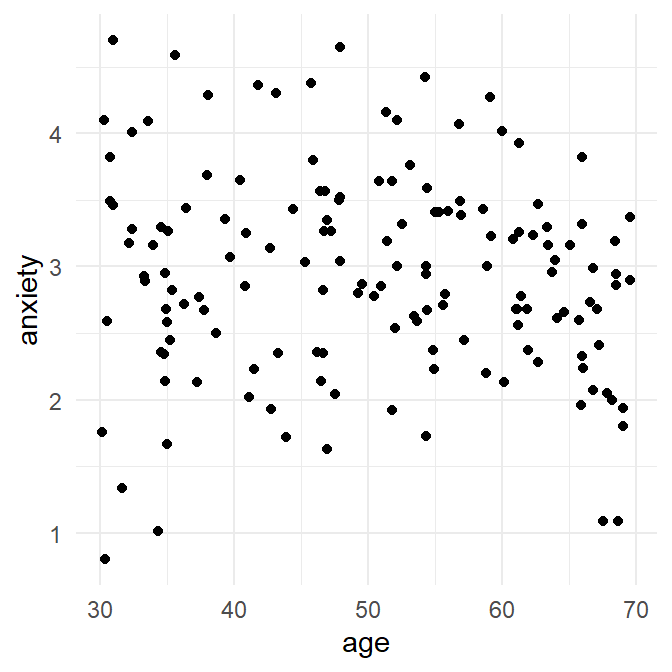

What kind of relationship between `age` and `anxiety` do you think is present?

A slight **bow** is evident in the plot such that `age` and `anxiety` seem to follow an inverted U-shaped relationship.  
Reported `anxiety` levels increase from 30 years to middle age (approx. 50 years) and then declines from 50 to 70 years. This mirrors the relationship we saw with `age` and `happiness` – `anxiety` appears greatest when `happiness` is lowest.

**Answer the following questions:**

**Linear component**

- What percentage of the variance in `anxiety` is explained by a model with `age` as the predictor? %

**Quadratic component**

- What percentage of the variance in `anxiety` is explained by a model containing both linear and quadratic components of `age` as predictors? %
- What is the *increase* in $R^2$ if a quadratic component of `age` is added to the model? %
- Does this increase represent a statistically significant increase?
- What is the *F*-statistic comparing the model with a linear component vs. one with linear and quadratic components? *F*(1, 147) = , *p* = .009

**Cubic component**

- What percentage of the variance in `anxiety` is explained by a model containing both linear, quadratic and cubic components of `age` as predictors? %
- What is the *increase* in $R^2$ if a cubic component of `age` is added to the model? %
- Does this increase represent a statistically significant increase?
- What is the *F*-statistic and *p*-value for the test of the model with a linear + quadratic component vs. linear + quadratic + cubic components? *F*(1, 146) = , *p* =

**Decision** - On the basis of the model comparison with ANOVA, which model should be preferred?

```r
# fit a linear model, show results
anx1 <- lm(anxiety ~ age, data = SurveyData)
summary(anx1)

# fit a quadratic component, show results
anx2 <- lm(anxiety ~ poly(age,2), data=SurveyData)
summary(anx2)

# compare linear and linear+quadratic models
anova(anx1, anx2)

# fit a cubic component
anx3 <- lm(anxiety ~ poly(age,3), data=SurveyData)
summary(anx3)

# compare (linear + quadratic) and (linear + quadratic + cubic) models
anova(anx2, anx3)
```

**Now use Bayes Factors:**

(Note: you do not need to re-add the quadratic and cubic components of age to `SurveyData`, as we did this before. These should still be in `SurveyData` as `age2` and `age3`.)

- The Bayes Factor comparing a model with linear and quadratic components vs. one with a linear component only is
- This indicates that there is more evidence for which model?
- The Bayes Factor comparing a model with linear, quadratic and cubic components vs. one with linear and quadratic components only is
- This indicates that there is more evidence for which model?

Do the comparisons of models with Bayes Factors agree with the conclusions made with anova?

```r
library(BayesFactor)

# BF for model anx1
anx1BF <- lmBF(anxiety ~ age, data = as.data.frame(SurveyData) )

# BF for model anx2
anx2BF <- lmBF(anxiety ~ age + age2, data = as.data.frame(SurveyData) )

# BF for model anx3
anx3BF <- lmBF(anxiety~ age + age2 + age3, data = as.data.frame(SurveyData) )

# compare BFs for anx2 and anx1
anx2BF / anx1BF
> Bayes factor analysis
> --------------
> [1] age + age2 : 5.476443 ±0%
>
> Against denominator:
>   anxiety ~ age
> ---
> Bayes factor type: BFlinearModel, JZS

# compare BFs for anx3 and anx2
anx3BF / anx2BF
> Bayes factor analysis
> --------------
> [1] age + age2 + age3 : 0.7556007 ±0%
>
> Against denominator:
>   anxiety ~ age + age2
> ---
> Bayes factor type: BFlinearModel, JZS
```

## 3.6 Summary of key points

- Polynomial terms (e.g., $x^2$, $x^3$) can be added to regression models to fit curves in our data.
- `poly(predictor name, X)` can be used with `lm` to specify models with polynomial terms of the Xth order.
  - The improvement in fit ($R^2$) as a result of adding in a polynomial term can be tested using `anova(polynomial1, polynomial2)`.
- Bayes Factors can also be used to compare models with polynomial terms using `lmBF`.
  - You must store the polynomial components in the dataset first before using `lmBF`. Use `poly(predictor name, X)[,"X"]`, where X is the order of the polynomial you will test (e.g., `poly(age, 3)[,"3"]`).
- **A note of caution**: Although curves of any complexity can be fit, it may not always be meaningful or parsimonious to do so.
  - Complex models may *overfit* the data and may not necessarily generalise to new datasets well.
  - It is also important not to extrapolate beyond the range of data used to generate the model when making predictions from the model, as the same relationship may not be present.

# 4 Assessment

Chris Berry is the lead for the Data Analysis and Visualisation task, worth 50% of the module grade. (Press the Right Arrow key for more details.)

## 4.1 Data Analysis and Visualisation Task

This assignment is due to be submitted to the DLE by the deadline of **12 noon on 21 January 2021**.

In overview, you are required to analyse a set of data with RStudio using techniques from the first half of the course, and submit a short report of your findings, in the style similar to that which you may expect to see in the results section of an academic journal. Further details are below.

### 4.1.1 Submitting your coursework

You should submit exactly 3 files:

1. An **Rmd (R markdown) file**
2. An **html** document, produced by *knitting* your rmd file.
3. As a separate document, upload a copy of the standard **coursework coversheet** (and complete the feedback section).

Within the Rmd file you should:

- Clearly set out the code that you have used for your analysis
- Where necessary, include comments explaining what specific lines of code do.
- Suppress code that you do not want to be visible in your report.

Your Rmd file should “Just Work” when the marker opens and runs it, and produce the same output as the knitted html file you submitted (i.e. there won’t be any errors or missing datafiles).

If you work on your own computer at home, you should check your Rmd file ‘knits’ correctly on the online Rstudio server.

### 4.1.2 Background and Dataset

Stories of tremendous personal drive, integrity, and achievement are common in the sporting world. However, not all individuals are motivated to compete in ways that might be deemed fair, and it is not uncommon to hear stories of cheating and gamesmanship (the use of dubious methods to win a competition).

The dataset held at https://bit.ly/335N974 contain responses to a survey, which was conducted to measure the values and attitudes of individuals who play sport. Demographic information was also collected from the respondents.

The variables in the dataset:

`age`: age in years

`gender`: female (0) or male (1)

`sportype`: whether the main sport is an individual (0) or team (1) sport

`perabil`: perceived ability. An individual’s self-perceived ability in their chosen sport. Higher scores indicate greater perceived ability.

`cheating`: attitude to cheating. Higher scores indicate a greater willingness to cheat to achieve success.

`gamesman`: attitude to gamesmanship. Higher scores indicate a greater willingness to use various ploys and tactics to gain a psychological advantage over competitors.

`commit`: commitment to sport participation. Higher scores indicate a greater commitment in terms of practising, effort, attempts to improve and persevere after making mistakes.

`conven`: respect for social conventions. Higher scores indicate a greater willingness to display sportsmanship (e.g., shaking hands with opponents, congratulating competitors).

`task`: perception of success and ability in sport, where success is measured relative to how well the *task* can actually be performed, and also relative to how well the task can be performed by oneself. Higher scores indicate greater perception of task-oriented success.

`ego`: perception of success and ability in sport, where success is measured in terms of how well one performs *relative to others*. Higher scores indicate greater perception of ego-oriented success.

### 4.1.3 Aims of the Assignment

Your principal objective is to visualise and analyse the dataset using techiques from the first half of the module (i.e., to session 8 on Fitting Curves). You should examine the variables in the dataset and identify interesting questions that you could ask; use these questions to guide the visualisations and analyses that you carry out.

At a minimum, you are expected to:

- Build a multiple regression model to predict one of the variables, and explain the model in your report.
- Create at least **one table** and **one figure** linked to the analysis; they should be of a standard that you would expect to see in an academic journal.
- Present statistics in APA style.
- Not exceed 1500 words in the the text of your html.

### 4.1.4 Tips

- Rather than just analysing the data all in one huge go, firstly work out what the questions are that seem interesting, and then apply the appropriate analyses and visualisation techniques to the relevant measures for answering them.
- It is often the case that interesting hypotheses or ways of visualising the data emerge after a period of reflection, rather than during the first attempt. Be willing to explore the relationships in the data, and then put them aside for a while, before doing further analyses.
- You are not required to use every technique from the first half of the course, or every variable in the dataset, in order to achieve a good mark.
- Select data and methods that will allow you to focus on questions that seem to make psychological or social sense.
- You can dig deeply into aspects of the data if they particularly interest you, but be prepared to justify what you have done. There is no one *correct answer* to this assignment, just as with real data there is not only one way of visualising or analysing it. Analyses are right or wrong in so far as they provide insight into the data and into the problems that are being researched. If you are not sure whether you are making the right choices in your analyses, then provide justification for them.
- In the end, keep in mind that the purpose of this assessment is for you to demonstrate that you can use the techniques from this course competently to answer questions concerning a dataset and present the findings coherently in a report.

### 4.1.5 Notes

The work submitted should be your own work. You may discuss the data with other students but cannot submit shared work. Please note university rules regarding plagiarism apply.

Reasonable amounts of assistance with technical aspects of RStudio may be obtained from the demonstrator for the course, Paul Sharpe, but this does not include recommending what you should choose to do, or helping with specific interpretations of output. As a general guide, if you are asking for something which would put you at an unfair advantage relative to any other student, then the request is probably unreasonable.

Submissions will be graded according to the School categorical mark scheme (i.e., A+ to N), as detailed in the handbook: https://pghandbook.psy.plymouth.ac.uk/assessment.html

**Responses to frequently asked questions will be posted at this FAQ link**

# 5 FAQ Data Analysis and Visualisation Task

### 5.0.1 How do I add a caption to a summary output table?

`pander()` can be used to output a summary table with a caption. Use the `caption=“XXX”` argument. For example:

```r
library(tidyverse)
library(pander)

mtcars %>%
  group_by(cyl) %>%
  summarise(mean_mpg = mean(mpg)) %>%
  pander(caption = "Mean miles per gallon by cyl")
```

Mean miles per gallon by cyl

| cyl | mean_mpg |
| --- | --- |
| 4 | 26.66 |
| 6 | 19.74 |
| 8 | 15.1 |

### 5.0.2 What does it mean if RStudio prints out “e-” next to a number?

If R prints “1.4e-4”, in the output this actually means “$1.4 \times 10^{-4}$”, or “0.00014”. It is a way of printing out very small (or very large) numbers.

“e-4” means “move the decimal point 4 places to the left”. See this by executing the command below – it should return “0.00014”.

```r
1.4e-4
> [1] 0.00014
```

So:

- “e-5” means move the decimal point 5 places to the left (e.g., `2.5e-5` is “$2.5 \times 10^{-5}$”, or 0.000025)
- “e-10” means move the decimal point 10 places to the left (e.g., `2.5e-10` is “$2.5 \times 10^{-10}$”, or 0.00000000025).
- “e5” means move the decimal point 5 places to the **right** (e.g., `2.5e5` is “$2.5 \times 10^{5}$”, 250000).

### 5.0.3 How do I set up an R Markdown file?

R-markdown is a way of embedding R code, figures, and text in a single executable document. (As an example, all the worksheets for this module were written in r-markdown.)

If you want to create an R markdown file, go to File > New File > R Markdown.

Slides to help get started are here: https://chrisjberry.github.io/datafluencyCB/slides/PSYC753_Chris2_Rmd.pptx

There’s a good cheat sheet here: - [R Markdown](https://github.com/rstudio/cheatsheets/raw/master/rmarkdown-2.0.pdf)